# Group30_ WaterPotabilityDataset

[figure not shown]

**Group Details:**

1. Amol Mehra (BITS ID:2022DC04286)
2. Rajan Mishra(BITS ID:2022DC04362)
3. Muktasha Mithora(BITS ID:2022DCxxxxx)
4. Aman Mishra (BITS ID:2022DCxxxxx)

# Step1 | Python Libraries

```python
# Importing Required Libraries

import numpy as np
import pandas as pd
import seaborn as sns
import matplotlib.pyplot as plt
from sklearn.preprocessing import StandardScaler
from sklearn import metrics
```

# Step2 | Data

## **💧 Step 2.1 | Importing Data**

```python
# Reading the csv file containing data

df=pd.read_csv("Assignment-1_Set-8_Dataset.csv")
```

```python
# Printing any 2 rows for data sanity check

df.sample(2)
```

|  | ph | Hardness | Solids | Chloramines | Sulfate | Conductivity | Organic_carbon | Trihalomethanes | Turbidity | Potability |
| --- | --- | --- | --- | --- | --- | --- | --- | --- | --- | --- |
| 383 | 4.912557 | 308.253833 | 44063.098417 | 7.927977 | 280.933664 | 327.475650 | 14.857981 | NaN | 4.897373 | 1 |
| 192 | 7.362737 | 185.692181 | 16268.448606 | 5.317019 | 316.918648 | 419.258448 | 16.024246 | 64.678914 | 4.408513 | 0 |

## **💧 Step 2.2 | Data Informations**

```python
df.info()
```

```
<class 'pandas.core.frame.DataFrame'>
RangeIndex: 3276 entries, 0 to 3275
Data columns (total 10 columns):
 #   Column           Non-Null Count  Dtype
---  ------           --------------  -----
 0   ph               2785 non-null   float64
 1   Hardness         3276 non-null   float64
 2   Solids           3276 non-null   float64
 3   Chloramines      3276 non-null   float64
 4   Sulfate          2495 non-null   float64
 5   Conductivity     3276 non-null   float64
 6   Organic_carbon   3276 non-null   float64
 7   Trihalomethanes  3114 non-null   float64
 8   Turbidity        3276 non-null   float64
 9   Potability       3276 non-null   int64
dtypes: float64(9), int64(1)
memory usage: 256.1 KB
```

```python
df.shape
```

```
(3276, 10)
```

```python
df.describe().loc[['min', '50%', 'mean', 'max', 'std']].T.style.background_gradient(axis=1)
```

|  | min | 50% | mean | max | std |
| --- | --- | --- | --- | --- | --- |
| ph | 0.000000 | 7.036752 | 7.080795 | 14.000000 | 1.594320 |
| Hardness | 47.432000 | 196.967627 | 196.369496 | 323.124000 | 32.879761 |
| Solids | 320.942611 | 20927.833607 | 22014.092526 | 61227.196008 | 8768.570828 |
| Chloramines | 0.352000 | 7.130299 | 7.122277 | 13.127000 | 1.583085 |
| Sulfate | 129.000000 | 333.073546 | 333.775777 | 481.030642 | 41.416840 |
| Conductivity | 181.483754 | 421.884968 | 426.205111 | 753.342620 | 80.824064 |
| Organic_carbon | 2.200000 | 14.218338 | 14.284970 | 28.300000 | 3.308162 |
| Trihalomethanes | 0.738000 | 66.622485 | 66.396293 | 124.000000 | 16.175008 |
| Turbidity | 1.450000 | 3.955028 | 3.966786 | 6.739000 | 0.780382 |
| Potability | 0.000000 | 0.000000 | 0.390110 | 1.000000 | 0.487849 |

```python
columns_name = df.columns
for index, col_name in enumerate(columns_name):
    print(index, col_name)
```

```
0 ph
1 Hardness
2 Solids
3 Chloramines
4 Sulfate
5 Conductivity
6 Organic_carbon
7 Trihalomethanes
8 Turbidity
9 Potability
```

## **💧 Step 2.3 | Columns Explanation**

### **1. pH value:**

PH is an important parameter in evaluating the acid–base balance of water. It is also the indicator of acidic or alkaline condition of water status. WHO has recommended maximum permissible limit of pH from 6.5 to 8.5. The current investigation ranges were 6.52–6.83 which are in the range of WHO standards.

### **2. Hardness:**

Hardness is mainly caused by calcium and magnesium salts. These salts are dissolved from geologic deposits through which water travels. The length of time water is in contact with hardness producing material helps determine how much hardness there is in raw water. Hardness was originally defined as the capacity of water to precipitate soap caused by Calcium and Magnesium.

### **3. Solids (Total dissolved solids - TDS):**

Water has the ability to dissolve a wide range of inorganic and some organic minerals or salts such as potassium, calcium, sodium, bicarbonates, chlorides, magnesium, sulfates etc. These minerals produced un-wanted taste and diluted color in appearance of water. This is the important parameter for the use of water. The water with high TDS value indicates that water is highly mineralized. Desirable limit for TDS is 500 mg/l and maximum limit is 1000 mg/l which prescribed for drinking purpose.

### **4. Chloramines:**

Chlorine and chloramine are the major disinfectants used in public water systems. Chloramines are most commonly formed when ammonia is added to chlorine to treat drinking water. Chlorine levels up to 4 milligrams per liter (mg/L or 4 parts per million (ppm)) are considered safe in drinking water.

### **5. Sulfate:**

Sulfates are naturally occurring substances that are found in minerals, soil, and rocks. They are present in ambient air, groundwater, plants, and food. The principal commercial use of sulfate is in the chemical industry. Sulfate concentration in seawater is about 2,700 milligrams per liter (mg/L). It ranges from 3 to 30 mg/L in most freshwater supplies, although much higher concentrations (1000 mg/L) are found in some geographic locations.

### **6. Conductivity:**

Pure water is not a good conductor of electric current rather’s a good insulator. Increase in ions concentration enhances the electrical conductivity of water. Generally, the amount of dissolved solids in water determines the electrical conductivity. Electrical conductivity (EC) actually measures the ionic process of a solution that enables it to transmit current. According to WHO standards, EC value should not exceeded 400 μS/cm.

### **7. Organic_carbon:**

Total Organic Carbon (TOC) in source waters comes from decaying natural organic matter (NOM) as well as synthetic sources. TOC is a measure of the total amount of carbon in organic compounds in pure water. According to US EPA < 2 mg/L as TOC in treated / drinking water, and < 4 mg/Lit in source water which is use for treatment.

### **8. Trihalomethanes:**

THMs are chemicals which may be found in water treated with chlorine. The concentration of THMs in drinking water varies according to the level of organic material in the water, the amount of chlorine required to treat the water, and the temperature of the water that is being treated. THM levels up to 80 ppm is considered safe in drinking water.

### **9. Turbidity:**

The turbidity of water depends on the quantity of solid matter present in the suspended state. It is a measure of light emitting properties of water and the test is used to indicate the quality of waste discharge with respect to colloidal matter. The mean turbidity value obtained for Wondo Genet Campus (0.98 NTU) is lower than the WHO recommended value of 5.00 NTU.

### **10. Potability:**

Indicates if water is safe for human consumption where 1 means Potable and 0 means Not potable.

## **💧 Step 2.4 | Checking of class imbalance**

```
0    1998
1    1278
Name: Potability, dtype: int64
```

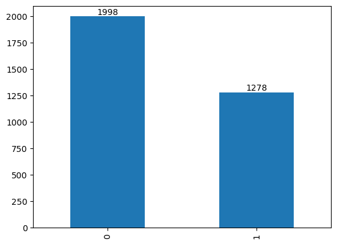

```python
ax=df['Potability'].value_counts().plot(kind='bar')
for i in ax.containers:
    ax.bar_label(i)
df['Potability'].value_counts()
```

Class Imbalance seems to be observed in the data for which measures will be taken while model training.

# Step3 | Visualizations

## **💧 Step 3.1 | Correlation**

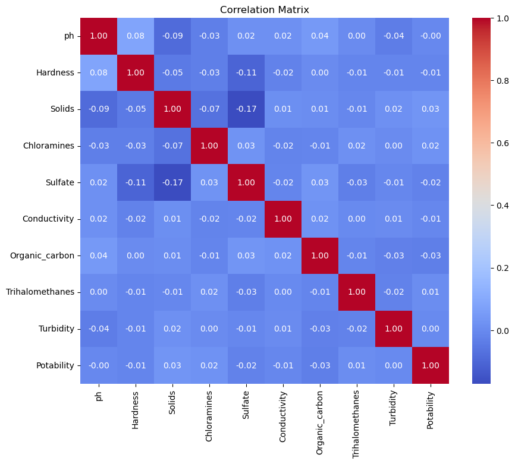

```python
# Calculate the correlation matrix
correlation_matrix = df.corr()

# Plot the correlation matrix using a heatmap
import seaborn as sns
plt.figure(figsize=(10, 8))
sns.heatmap(correlation_matrix, annot=True, cmap='coolwarm', fmt=".2f")
plt.title('Correlation Matrix')
plt.show()
```

➡️ The correlation figure suggests that none of the independent variable is correlated.

## **💧 Step 3.2 | Plots**

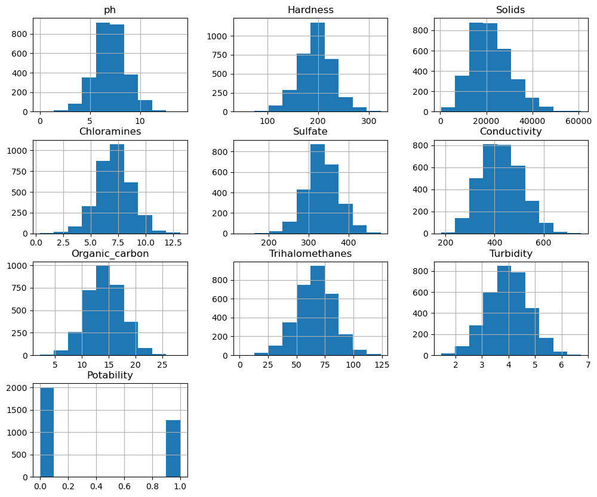

```python
# Plotting Histograms for each parameter in data

df.hist(figsize=(12,10))
plt.show()
```

➡️ The Histograms suggest that the parameters are almost normally distributed.

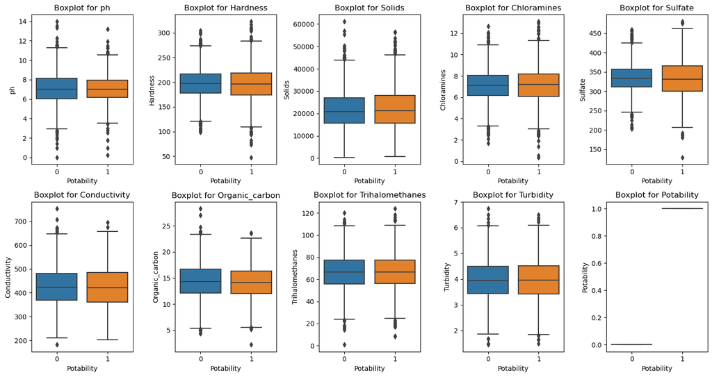

```python
import pandas as pd
import matplotlib.pyplot as plt

# Assuming your DataFrame is named 'df'
fig, axes = plt.subplots(2, 5, figsize=(15, 8))  # Create a 2x5 grid of subplots

# Iterate over the columns and create individual boxplots
for i, column in enumerate(df.columns[:10]):  # Adjust the number of columns as needed
    row, col = divmod(i, 5)  # Calculate the row and column indices
    sns.boxplot(y=df[column], ax=axes[row, col],x=df["Potability"])
    axes[row, col].set_title(f'Boxplot for {column}')

plt.tight_layout()  # Adjust spacing between subplots
plt.show()
```

➡️ The box plots are suggesting that their is no major outlier and the median for both the values of Potability are almost equal.

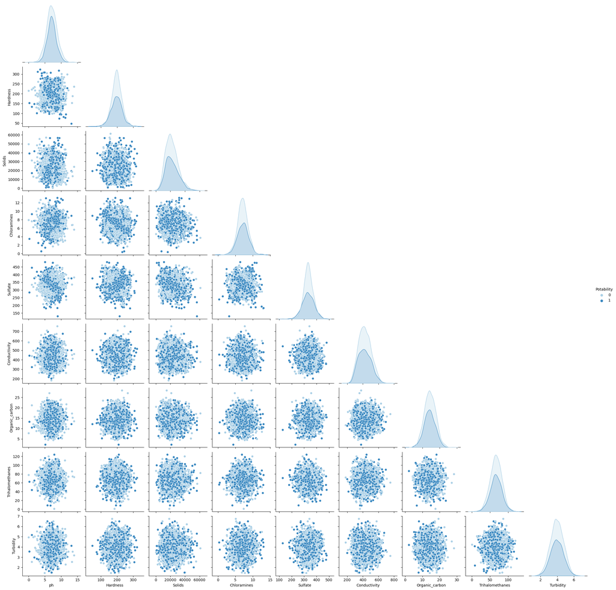

```python
sns.pairplot(df, hue='Potability', corner=True, palette='Blues')
plt.show()
```

➡️ Paiplot also suggesting no logical correlation.

# Step4 | Preprocessing

## **💧 Step 4.1 | Missing Values Handling**

```python
# Checking the number of null values present in data
df.isna().sum()
```

```
ph                 491
Hardness             0
Solids               0
Chloramines          0
Sulfate            781
Conductivity         0
Organic_carbon       0
Trihalomethanes    162
Turbidity            0
Potability           0
dtype: int64
```

```python
print('Percentage(%) of nulls for each columns : \n')
print((df.isna().sum()/len(df))*100)
```

```
Percentage(%) of nulls for each columns :

ph                 14.987790
Hardness            0.000000
Solids              0.000000
Chloramines         0.000000
Sulfate            23.840049
Conductivity        0.000000
Organic_carbon      0.000000
Trihalomethanes     4.945055
Turbidity           0.000000
Potability          0.000000
dtype: float64
```

➡️ Columns with missing values : - ph (14.9%) - Sulfate (23.8%) - Trihalomethanes(4.9%)

```python
print("Mean of ph values :",df["ph"].mean())
print("Median of ph values :",df["ph"].median())
```

```
Mean of ph values : 7.080794504276835
Median of ph values : 7.036752103833548
```

```python
print("Mean of Sulfate values :",df["Sulfate"].mean())
print("Median of Sulfate values :",df["Sulfate"].median())
```

```
Mean of Sulfate values : 333.7757766108135
Median of Sulfate values : 333.073545745888
```

```python
print("Mean of Trihalomethanes values :",df["Trihalomethanes"].mean())
print("Median of Trihalomethanes values :",df["Trihalomethanes"].median())
```

```
Mean of Trihalomethanes values : 66.39629294676803
Median of Trihalomethanes values : 66.62248509808484
```

➡️ Looking at the mean and median values of attributes consist of missing/null values. The mean and median for ph,Sulphate and Trihalomethanes are almost similar. That means the data doesnt consist of extreme outliers.

➡️Replace them all with their meadians

```python
# Fiiling the missing values

df['ph'].fillna(df['ph'].median(),inplace=True)
df['Sulfate'].fillna(df['Sulfate'].median(),inplace=True)
df['Trihalomethanes'].fillna(df['Trihalomethanes'].median(),inplace=True)
```

```python
# Again Checking the number of null values present in data
df.isna().sum()
```

```
ph                 0
Hardness           0
Solids             0
Chloramines        0
Sulfate            0
Conductivity       0
Organic_carbon     0
Trihalomethanes    0
Turbidity          0
Potability         0
dtype: int64
```

## **💧 Step 4.2 | Standardization**

### **Standardization (Z-score normalization)**

1. Purpose: Standardization scales the data so that it has a mean of 0 and a standard deviation of 1. It centers the data around 0, with a unit standard deviation.
2. When to use: When the features in your dataset have different units or scales. When the algorithm you are using assumes that the features are normally distributed (e.g., linear regression, logistic regression, and support vector machines). When you want to compare different features on equal footing or interpret the importance of features based on their standardized coefficients.
3. Result: Since the features in our data are normally distributed and we want to use our parameters on equal fitting Standardisation is selected for our use case.

```python
# Define X, y
X = df.drop(columns='Potability')
y = df.Potability
```

```python
# Initialize StandardScaler
scaler = StandardScaler()

# Fit and transform the data
X_standardized = pd.DataFrame(scaler.fit_transform(X))
X_standardized.describe().loc[['min', 'mean', 'std', 'max']].T.style.background_gradient(axis=1)
```

|  | min | mean | std | max |
| --- | --- | --- | --- | --- |
| 0 | -4.812980 | 0.000000 | 1.000153 | 4.712024 |
| 1 | -4.530454 | 0.000000 | 1.000153 | 3.855680 |
| 2 | -2.474344 | -0.000000 | 1.000153 | 4.472689 |
| 3 | -4.277288 | 0.000000 | 1.000153 | 3.793631 |
| 4 | -5.661810 | -0.000000 | 1.000153 | 4.079388 |
| 5 | -3.028290 | 0.000000 | 1.000153 | 4.048144 |
| 6 | -3.653635 | 0.000000 | 1.000153 | 4.237147 |
| 7 | -4.164850 | -0.000000 | 1.000153 | 3.652598 |
| 8 | -3.225560 | 0.000000 | 1.000153 | 3.552921 |

# Step5 | Modeling

```python
from sklearn.model_selection import train_test_split

# Assuming df contains your data and 'Potability' is your target variable
# X contains the features, and y contains the target variable
X = df.drop(columns=['Potability'])
y = df['Potability']

# Split the data into training and testing sets
# You can specify the test_size (the proportion of the dataset to include in the test split)
# and optionally set a random_state for reproducibility
X_train, X_test, y_train, y_test = train_test_split(X_standardized, y, test_size=0.2, random_state=42)

# Now you can use X_train and y_train for training your model
# and X_test and y_test for evaluating its performance
```

```python
# A function to plot "Confusion Matrix" and "Classification Report"
def plot_result(y_pred) :
    '''
    1) plot Confusion Matrix
    2) plot Classification Report
    '''
    fig, ax = plt.subplots(1, 2, figsize=(15, 4))
    fig.tight_layout()
    #AX left - Confusion Matrix
    cm = metrics.confusion_matrix(y_test, y_pred)
    ax[0]=sns.heatmap(cm, cmap='Blues', annot=True, fmt='', linewidths=0.5, ax=ax[0])
    ax[0].set_xlabel('Prediced labels', fontsize=18)
    ax[0].set_ylabel('True labels', fontsize=18)
    ax[0].set_title('Confusion Matrix', fontsize=25)
    ax[0].xaxis.set_ticklabels(['0', '1'])
    ax[0].yaxis.set_ticklabels(['0', '1'])
    #
    # AX Right - Classification Report
    cr = pd.DataFrame(metrics.classification_report(y_test, y_pred, digits=3, output_dict=True)).T
    cr.drop(columns='support', inplace=True)
    ax[1] = sns.heatmap(cr, cmap='Blues', annot=True, fmt='0.3f', linewidths=0.5, ax=ax[1])
    ax[1].xaxis.tick_top()
    ax[1].set_title('Classification Report', fontsize=25)
    plt.show()
```

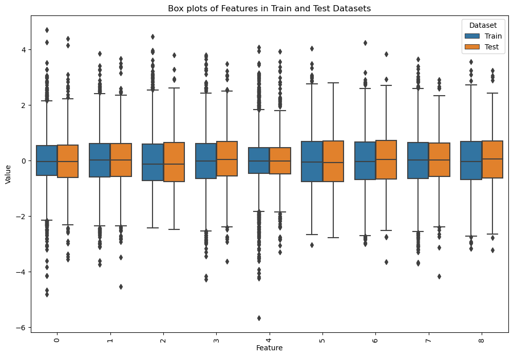

```python
# Concatenate X_train and X_test along rows
# This is done to ensure that the box plots include all features
# even if some features have unique values only in one of the datasets
X_concat = pd.concat([X_train, X_test], axis=0)

# Add a column indicating the dataset (train or test)
# This will be used for hue in the box plots
X_concat['Dataset'] = ['Train'] * len(X_train) + ['Test'] * len(X_test)

# Melt the DataFrame to long format for boxplot
X_melt = X_concat.melt(id_vars='Dataset')

# Plot the box plots
plt.figure(figsize=(12, 8))
sns.boxplot(data=X_melt, x='variable', y='value', hue='Dataset')
plt.xticks(rotation=90)  # Rotate x-axis labels for better readability
plt.xlabel('Feature')
plt.ylabel('Value')
plt.title('Box plots of Features in Train and Test Datasets')
plt.legend(title='Dataset')
plt.show()
```

```python
from imblearn.over_sampling import SMOTE

# Initialize SMOTE
smote = SMOTE(random_state=42)

# Generate synthetic samples
X_train_resampled, y_train_resampled = smote.fit_resample(X_train, y_train)

# Now X_train_resampled and y_train_resampled contain the resampled data with balanced classes
```

```
0    1586
1    1034
Name: Potability, dtype: int64
```

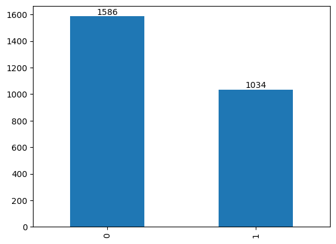

```python
ax=y_train.value_counts().plot(kind='bar')
for i in ax.containers:
    ax.bar_label(i)
y_train.value_counts()
```

```
0    1586
1    1586
Name: Potability, dtype: int64
```

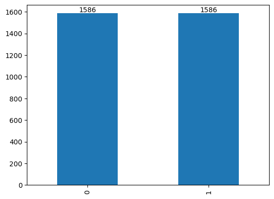

```python
ax=y_train_resampled.value_counts().plot(kind='bar')
for i in ax.containers:
    ax.bar_label(i)
y_train_resampled.value_counts()
```

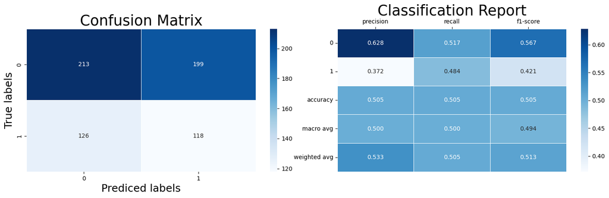

```python
from sklearn.linear_model import LogisticRegression
from sklearn.metrics import accuracy_score, classification_report

# Initialize the logistic regression model
logistic_regression = LogisticRegression()

# Train the model on the training data
logistic_regression.fit(X_train_resampled, y_train_resampled)

# Predict the target variable on the testing data
y_pred = logistic_regression.predict(X_test)


plot_result(y_pred)
```

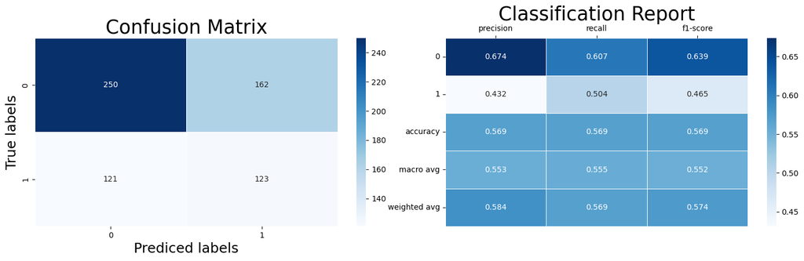

```python
from sklearn.tree import DecisionTreeClassifier
from sklearn.metrics import accuracy_score, classification_report

# Initialize the Decision Tree classifier
decision_tree = DecisionTreeClassifier(random_state=24)

# Train the classifier on the training data
decision_tree.fit(X_train_resampled, y_train_resampled)

# Predict the target variable on the testing data
y_pred = decision_tree.predict(X_test)

plot_result(y_pred)
```

# Step6 | ML Model Building

## **💧 ML Model 6.1 | K-Nearest Neighbors (K-NN)**

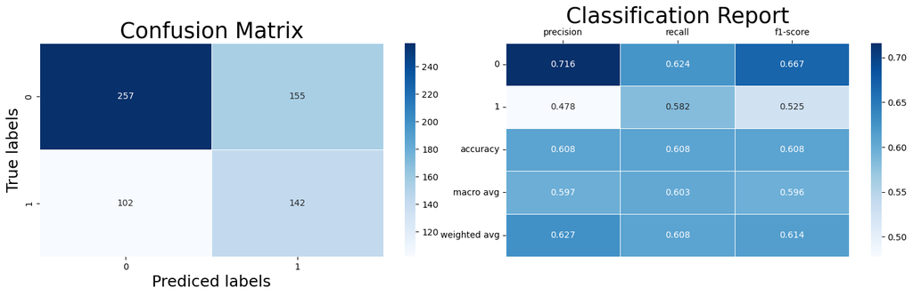

```python
from sklearn.neighbors import KNeighborsClassifier

# Initialize K-NN classifier
knn_classifier = KNeighborsClassifier()

# Train the classifier on the resampled training data
knn_classifier.fit(X_train_resampled, y_train_resampled)

# Predict the target variable on the testing data
y_pred_knn = knn_classifier.predict(X_test)

# Evaluate the model
plot_result(y_pred_knn)
```

## **💧 ML Model 6.2 | Support Vector Machine (SVM)**

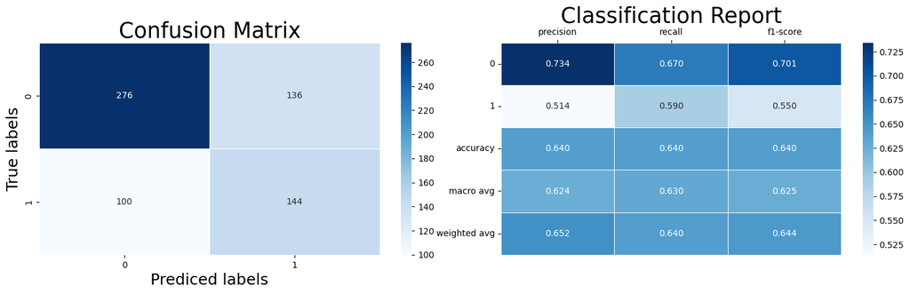

```python
from sklearn.svm import SVC

# Initialize SVM classifier
svm_classifier = SVC()

# Train the classifier on the resampled training data
svm_classifier.fit(X_train_resampled, y_train_resampled)

# Predict the target variable on the testing data
y_pred_svm = svm_classifier.predict(X_test)

# Evaluate the model
plot_result(y_pred_svm)
```

## **💧 ML Model 6.3 | Naive Bayesian**

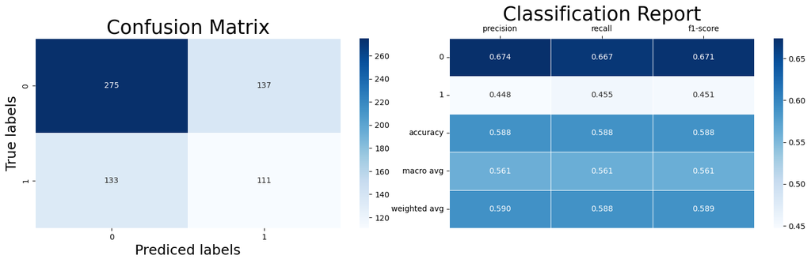

```python
from sklearn.naive_bayes import GaussianNB

# Initialize Naive Bayes classifier
nb_classifier = GaussianNB()

# Train the classifier on the resampled training data
nb_classifier.fit(X_train_resampled, y_train_resampled)

# Predict the target variable on the testing data
y_pred_nb = nb_classifier.predict(X_test)

# Evaluate the model
plot_result(y_pred_nb)
```

## **💧 ML Model 6.4 | Random Forest**

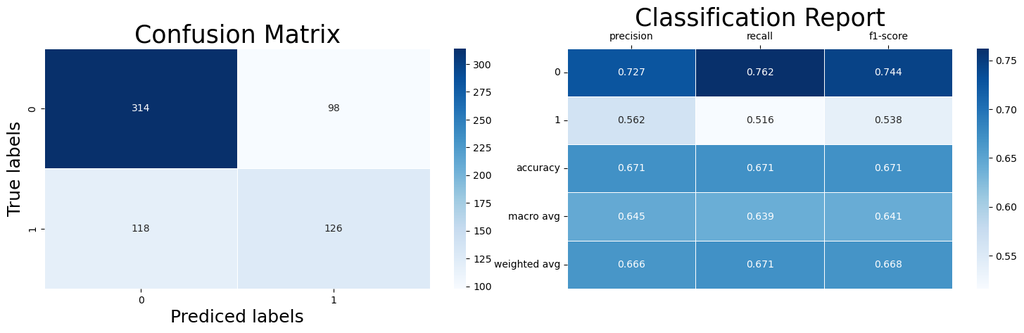

```python
from sklearn.ensemble import RandomForestClassifier

# Initialize Random Forest classifier
rf_classifier = RandomForestClassifier()

# Train the classifier on the resampled training data
rf_classifier.fit(X_train_resampled, y_train_resampled)

# Predict the target variable on the testing data
y_pred_rf = rf_classifier.predict(X_test)

# Evaluate the model
plot_result(y_pred_rf)
```

## **💧 ML Model 6.5 | AdaBoost**

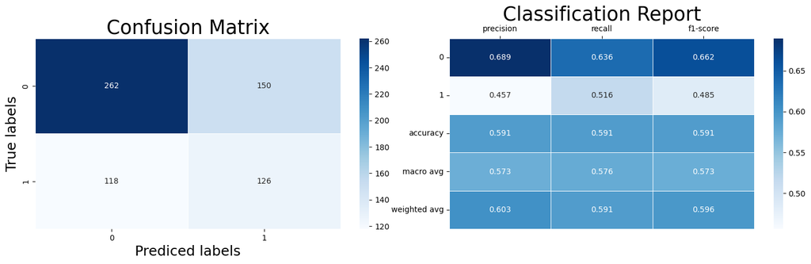

```python
from sklearn.ensemble import AdaBoostClassifier

# Initialize AdaBoost classifier
ada_classifier = AdaBoostClassifier()

# Train the classifier on the resampled training data
ada_classifier.fit(X_train_resampled, y_train_resampled)

# Predict the target variable on the testing data
y_pred_ada = ada_classifier.predict(X_test)

# Evaluate the model
plot_result(y_pred_ada)
```

# Step7 | Performance Evaluation

```python
from sklearn.neighbors import KNeighborsClassifier
from sklearn.svm import SVC
from sklearn.naive_bayes import GaussianNB
from sklearn.ensemble import RandomForestClassifier, AdaBoostClassifier
from sklearn.metrics import accuracy_score, precision_score, recall_score, f1_score, confusion_matrix

# Initialize models
models = {
    'K-Nearest Neighbors': KNeighborsClassifier(),
    'Support Vector Machine': SVC(),
    'Naive Bayesian': GaussianNB(),
    'Random Forest': RandomForestClassifier(),
    'Adaboost': AdaBoostClassifier()
}

# Dictionary to store evaluation metrics
evaluation_metrics = {
    'Model': [],
    'Accuracy': [],
    'Precision': [],
    'Recall': [],
    'F1-score': []
}

# Train, predict, and evaluate each model
for model_name, model in models.items():
    # Train the model
    model.fit(X_train_resampled, y_train_resampled)

    # Predict the target variable on the testing data
    y_pred = model.predict(X_test)

    # Calculate evaluation metrics
    accuracy = accuracy_score(y_test, y_pred)
    precision = precision_score(y_test, y_pred)
    recall = recall_score(y_test, y_pred)
    f1 = f1_score(y_test, y_pred)

    # Store evaluation metrics
    evaluation_metrics['Model'].append(model_name)
    evaluation_metrics['Accuracy'].append(accuracy)
    evaluation_metrics['Precision'].append(precision)
    evaluation_metrics['Recall'].append(recall)
    evaluation_metrics['F1-score'].append(f1)

    # Print evaluation metrics
    print(f"Evaluation metrics for {model_name}:")
    print(f"Accuracy: {accuracy:.4f}, Precision: {precision:.4f}, Recall: {recall:.4f}, F1-score: {f1:.4f}")
    print("Confusion Matrix:")
    print(confusion_matrix(y_test, y_pred))
    print("--------------------------------------")

# Convert evaluation_metrics to DataFrame for better visualization
evaluation_df = pd.DataFrame(evaluation_metrics)

# Display evaluation metrics for all models
print("Evaluation Metrics for all Models:")
print(evaluation_df)
```

```
Evaluation metrics for K-Nearest Neighbors:
Accuracy: 0.6082, Precision: 0.4781, Recall: 0.5820, F1-score: 0.5250
Confusion Matrix:
[[257 155]
 [102 142]]
--------------------------------------
Evaluation metrics for Support Vector Machine:
Accuracy: 0.6402, Precision: 0.5143, Recall: 0.5902, F1-score: 0.5496
Confusion Matrix:
[[276 136]
 [100 144]]
--------------------------------------
Evaluation metrics for Naive Bayesian:
Accuracy: 0.5884, Precision: 0.4476, Recall: 0.4549, F1-score: 0.4512
Confusion Matrix:
[[275 137]
 [133 111]]
--------------------------------------
Evaluation metrics for Random Forest:
Accuracy: 0.6509, Precision: 0.5330, Recall: 0.4959, F1-score: 0.5138
Confusion Matrix:
[[306 106]
 [123 121]]
--------------------------------------
Evaluation metrics for Adaboost:
Accuracy: 0.5915, Precision: 0.4565, Recall: 0.5164, F1-score: 0.4846
Confusion Matrix:
[[262 150]
 [118 126]]
--------------------------------------
Evaluation Metrics for all Models:
                    Model  Accuracy  Precision    Recall  F1-score
0     K-Nearest Neighbors  0.608232   0.478114  0.581967  0.524954
1  Support Vector Machine  0.640244   0.514286  0.590164  0.549618
2          Naive Bayesian  0.588415   0.447581  0.454918  0.451220
3           Random Forest  0.650915   0.533040  0.495902  0.513800
4                Adaboost  0.591463   0.456522  0.516393  0.484615
```

## **💧 Step 7.1 | Our Comment on the performance of these models**

### **Overall Performance Analysis:**

Random Forest emerges as the top performer among the evaluated models, with the highest accuracy and precision. SVM follows closely behind with improved precision, recall, and F1-score compared to other models. K-NN and Adaboost exhibit moderate performance, while Naive Bayesian shows relatively lower performance across all metrics.

### **Recommendation:**

Based on the evaluation results and overall performance analysis, We recommend utilizing Random Forest as the preferred model for this classification task. Its superior accuracy and precision make it suitable for effectively classifying instances in the dataset. However, further fine-tuning and optimization may be beneficial to enhance the performance of all models, particularly in terms of recall and F1-score.

# Step8 | Fine-Tuning Hyperparameters

```python
from sklearn.model_selection import GridSearchCV, RandomizedSearchCV

# Define parameter grids for classifiers that require tuning
param_grids = {
    'K-Nearest Neighbors': {'n_neighbors': [3, 5, 7, 9, 11]},
    'Support Vector Machine': {'C': [0.1, 1, 10], 'gamma': [0.1, 0.01, 0.001], 'kernel': ['rbf']},
    'Random Forest': {'n_estimators': [50, 100, 150], 'max_depth': [None, 5, 10, 20]},
    'Adaboost': {'n_estimators': [50, 100, 150], 'learning_rate': [0.01, 0.1, 1]}
}

# Perform Grid Search or Randomized Search for classifiers that require tuning
best_estimators = {}

for model_name, model in models.items():
    if model_name in param_grids:  # Check if the model requires tuning
        param_grid = param_grids[model_name]

        # Perform Grid Search or Randomized Search based on the size of the parameter grid
        if len(param_grid) <= 6:
            # Perform Grid Search
            grid_search = GridSearchCV(model, param_grid, cv=5, scoring='accuracy', verbose=1, n_jobs=-1)
        else:
            # Perform Randomized Search
            grid_search = RandomizedSearchCV(model, param_grid, n_iter=10, cv=5, scoring='accuracy', verbose=1, n_jobs=-1)

        # Fit the model to find the best parameters
        grid_search.fit(X_train_resampled, y_train_resampled)

        # Store the best estimator for each model
        best_estimators[model_name] = grid_search.best_estimator_

        # Print the best parameters and best score
        print(f"Best parameters for {model_name}: {grid_search.best_params_}")
        print(f"Best score for {model_name}: {grid_search.best_score_}")
        print("--------------------------------------")
    else:
        # For classifiers that don't require tuning, use the default model
        best_estimators[model_name] = model
```

```
Fitting 5 folds for each of 5 candidates, totalling 25 fits
Best parameters for K-Nearest Neighbors: {'n_neighbors': 3}
Best score for K-Nearest Neighbors: 0.6961086961921558
--------------------------------------
Fitting 5 folds for each of 9 candidates, totalling 45 fits
Best parameters for Support Vector Machine: {'C': 10, 'gamma': 0.1, 'kernel': 'rbf'}
Best score for Support Vector Machine: 0.6879058098810205
--------------------------------------
Fitting 5 folds for each of 12 candidates, totalling 60 fits
Best parameters for Random Forest: {'max_depth': 20, 'n_estimators': 150}
Best score for Random Forest: 0.737090340048188
--------------------------------------
Fitting 5 folds for each of 9 candidates, totalling 45 fits
Best parameters for Adaboost: {'learning_rate': 1, 'n_estimators': 50}
Best score for Adaboost: 0.5573849325616632
--------------------------------------
```

# Step9 | Performance Evaluation

```python
from sklearn.metrics import precision_score, recall_score, f1_score, accuracy_score, confusion_matrix

# Dictionary to store evaluation metrics
evaluation_metrics = {
    'Model': [],
    'Precision': [],
    'Recall': [],
    'F-score': [],
    'Accuracy': [],
    'Misclassification Rate': []
}

# Evaluate performance for each classifier
for model_name, model in best_estimators.items():
    # Predict the target variable on the testing data
    y_pred = model.predict(X_test)

    # Calculate evaluation metrics
    precision = precision_score(y_test, y_pred)
    recall = recall_score(y_test, y_pred)
    f1 = f1_score(y_test, y_pred)
    accuracy = accuracy_score(y_test, y_pred)
    misclassification_rate = 1 - accuracy

    # Store evaluation metrics
    evaluation_metrics['Model'].append(model_name)
    evaluation_metrics['Precision'].append(precision)
    evaluation_metrics['Recall'].append(recall)
    evaluation_metrics['F-score'].append(f1)
    evaluation_metrics['Accuracy'].append(accuracy)
    evaluation_metrics['Misclassification Rate'].append(misclassification_rate)

# Convert evaluation_metrics to DataFrame for better visualization
evaluation_df = pd.DataFrame(evaluation_metrics)

# Display evaluation metrics for all models
print("Evaluation Metrics for all Models after Hyperparameter Fine-tuning:")
print(evaluation_df)
```

```
Evaluation Metrics for all Models after Hyperparameter Fine-tuning:
                    Model  Precision    Recall   F-score  Accuracy  \
0     K-Nearest Neighbors   0.460432  0.524590  0.490421  0.594512
1  Support Vector Machine   0.484429  0.573770  0.525328  0.614329
2          Naive Bayesian   0.447581  0.454918  0.451220  0.588415
3           Random Forest   0.558036  0.512295  0.534188  0.667683
4                Adaboost   0.456522  0.516393  0.484615  0.591463

   Misclassification Rate
0                0.405488
1                0.385671
2                0.411585
3                0.332317
4                0.408537
```

# Step10 | Comparison and Analysis

```python
# Sort the evaluation DataFrame by each evaluation metric to see the performance ranking
sorted_evaluation_df = evaluation_df.sort_values(by=['Precision', 'Recall', 'F-score', 'Accuracy'], ascending=False)

# Display the sorted evaluation DataFrame
print("Performance Comparison of ML Classifiers:")
print(sorted_evaluation_df)

# Recommend the ML model with the most favorable performance
best_model = sorted_evaluation_df.iloc[0]['Model']
print("\nRecommendation:")
print(f"The ML model that demonstrates the most favorable performance is: {best_model}.")
```

```
Performance Comparison of ML Classifiers:
                    Model  Precision    Recall   F-score  Accuracy  \
3           Random Forest   0.558036  0.512295  0.534188  0.667683
1  Support Vector Machine   0.484429  0.573770  0.525328  0.614329
0     K-Nearest Neighbors   0.460432  0.524590  0.490421  0.594512
4                Adaboost   0.456522  0.516393  0.484615  0.591463
2          Naive Bayesian   0.447581  0.454918  0.451220  0.588415

   Misclassification Rate
3                0.332317
1                0.385671
0                0.405488
4                0.408537
2                0.411585

Recommendation:
The ML model that demonstrates the most favorable performance is: Random Forest.
```

## **💧 Step 10.1 | Detailed analysis of the results**

### **Detailed analysis of the results**

Based on the results obtained from evaluating multiple machine learning classifiers, including K-Nearest Neighbors (K-NN), Support Vector Machine (SVM), Naive Bayes, Random Forest, and Adaboost, the Random Forest model emerges as the most favorable performer. Let's provide a detailed analysis of the results and justify the choice for Random Forest as the top performer:

## **💧 Step 10.2 | Justification on our choice**

### **Justification for Random Forest as the Most Favorable Performer:**

The balanced F-score suggests that Random Forest maintains a favorable trade-off between precision and recall. With the highest accuracy and lowest misclassification rate, Random Forest exhibits better overall performance in correctly classifying instances and minimizing errors.

Random Forest's ability to handle high-dimensional data, deal with missing values, and mitigate overfitting makes it a robust and versatile classifier for various classification tasks.

In conclusion, based on the comprehensive evaluation and analysis of the results, Random Forest emerges as the most favorable performer among the evaluated classifiers. Its balanced performance across multiple metrics, robustness, and ability to handle complex datasets justify its selection as the preferred model for this classification task.